# ATAC-seq Differential Accessibility Analysis with DiffBind

To identify chromatin regions with different accessibility between WT and KO conditions in cDC1 and cDC2 cells, we will perform Diffbind, DESeq2, and TMM normalization as per Fernandes et al. 2024.

We will first create an output directory for results.

```r
dir.create("results/diffbind", showWarnings = FALSE, recursive = TRUE)
```

Then, we will prepare sample information for cDC1 and cDC2.

```r
samples_cdc1 <- data.frame(
  SampleID = c("WT1_rep1", "WT2_rep1", "KO1_rep1", "KO2_rep1"),
  Condition = c("WT", "WT", "KO", "KO"),
  Replicate = c(1, 2, 1, 2),
  bamReads = paste0("results/samtools_idx/", c("WT1_rep1", "WT2_rep1", "KO1_rep1", "KO2_rep1"), ".noMT.bam"),
  Peaks = paste0("results/macs3_callpeaks/", c("WT1_rep1", "WT2_rep1", "KO1_rep1", "KO2_rep1"), "_peaks.narrowPeak"),
  PeakCaller = "narrowPeak"
)

samples_cdc2 <- data.frame(
  SampleID = c("WT1_rep2", "WT2_rep2", "KO1_rep2", "KO2_rep2"),
  Condition = c("WT", "WT", "KO", "KO"),
  Replicate = c(1, 2, 1, 2),
  bamReads = paste0("results/samtools_idx/", c("WT1_rep2", "WT2_rep2", "KO1_rep2", "KO2_rep2"), ".noMT.bam"),
  Peaks = paste0("results/macs3_callpeaks/", c("WT1_rep2", "WT2_rep2", "KO1_rep2", "KO2_rep2"), "_peaks.narrowPeak"),
  PeakCaller = "narrowPeak"
)
```

We will first perform analysis on cDC1 cells.

```r
# read sample sheet and loads all peak files into a DiffBind object
dba_cdc1 <- dba(sampleSheet = samples_cdc1)
```

We will then count the reads in consensus peaks, which consists of creating consensus peaks where peaks must appear in at least 2 samples (`minOverlap` = 2), counting how many ATAC-seq reads from each BAM file overlap each consensus peak, and normalizing with TMM (Trimmed Mean of M-values) to account for library size differences. This results in a count matrix where rows = peaks and columns = samples.

```r
dba_cdc1 <- dba.count(dba_cdc1, minOverlap = 2, score = DBA_SCORE_TMM_MINUS_FULL)
```

Then, we will set up a comparison between WT and KO conditions. This requires at least 2 samples per group (`minMembers` = 2).

```r
dba_cdc1 <- dba.contrast(dba_cdc1, categories = DBA_CONDITION, minMembers = 2)
```

We will now run statistical analysis with DESeq2. DESEq2 will model count data with negative binomial distribution, estimate variance between replicates, and calculate p-values to determine if differences are significant. Since we already filtered ENCODE blacklist regions, `bBlacklist` and `bGreylist` are set to FALSE.

```r
dba_cdc1 <- dba.analyze(dba_cdc1, method = DBA_DESEQ2, bBlacklist = FALSE, bGreylist = FALSE)
```

We will then extract results. `th = 1` (p-value < 1) extracts ALL peaks. `bCounts = FALSE` excludes raw read counts, which keeps the file smaller. The results include coordinates, fold change (KO vs. WT), p-value, and FDR.

```r
diff_cdc1_df <- as.data.frame(dba.report(dba_cdc1, th = 1, bCounts = FALSE))

# add column marking significant peaks (p < 0.01 as per paper)
diff_cdc1_df$significant <- diff_cdc1_df$p.value < 0.01
```

We will then save our results.

```r
write.csv(diff_cdc1_df, "results/diffbind/cdc1_diffbind_results.csv", row.names = FALSE)

# save only significant peaks as BED file for downstream analysis (motif finding, annotation, etc.)
write.table(diff_cdc1_df[diff_cdc1_df$p.value < 0.01, c("seqnames", "start", "end")],
            "results/diffbind/cdc1_significant_peaks.bed",
            sep = "\t", quote = FALSE, row.names = FALSE, col.names = FALSE)
```

Finally, we will generate visualizations, including an MA plot, volcano plot, PCA plot, and heatmap.

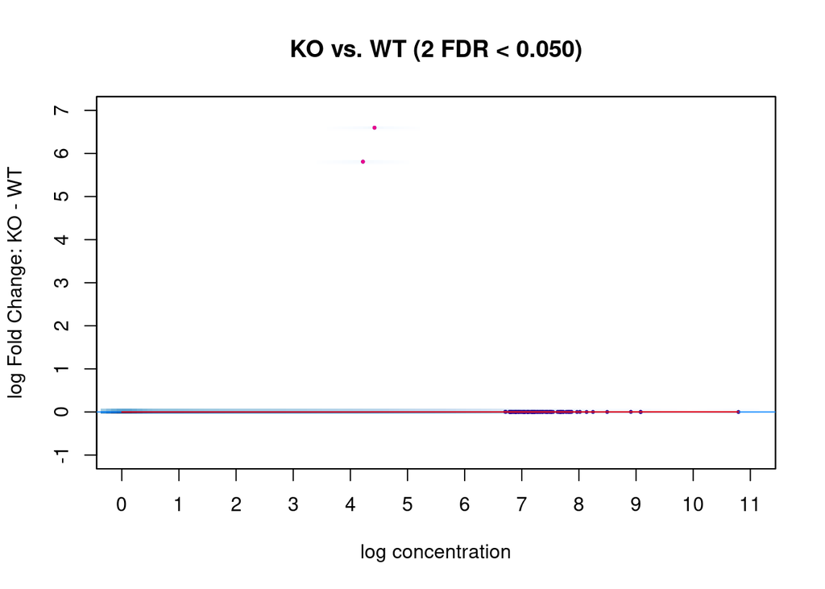

```r
# MA plot: shows fold change vs average expression (red = significant)
dba.plotMA(dba_cdc1)
```

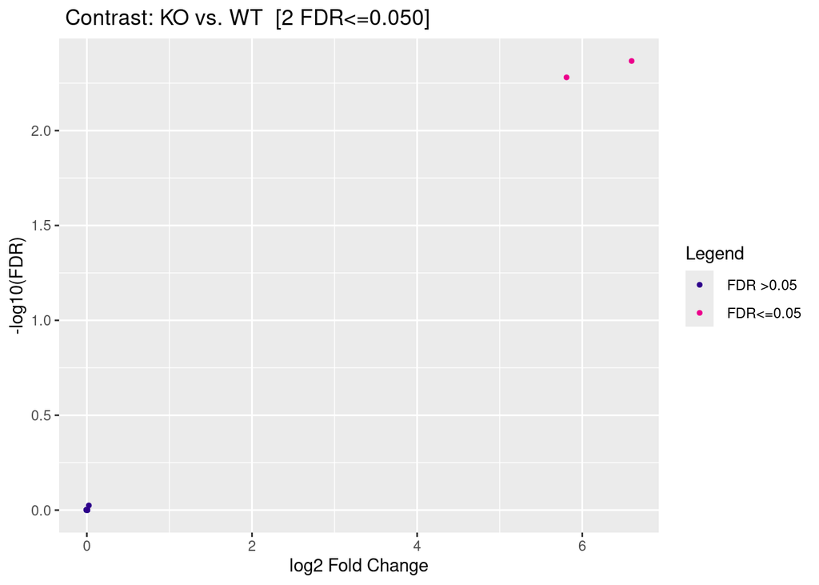

```r
# volcano plot: shows fold change vs significance (points far from center = interesting)
dba.plotVolcano(dba_cdc1)
```

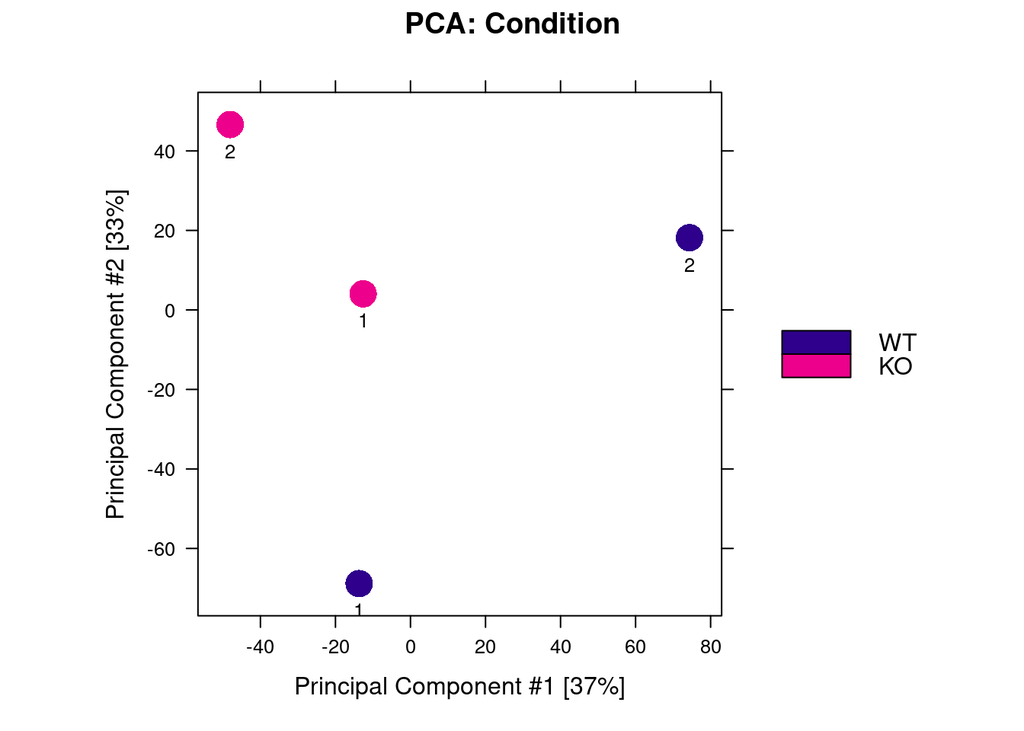

```r
# PCA plot: shows how similar samples are (different conditions should cluster together)
dba.plotPCA(dba_cdc1, attributes = DBA_CONDITION, label = DBA_REPLICATE)
```

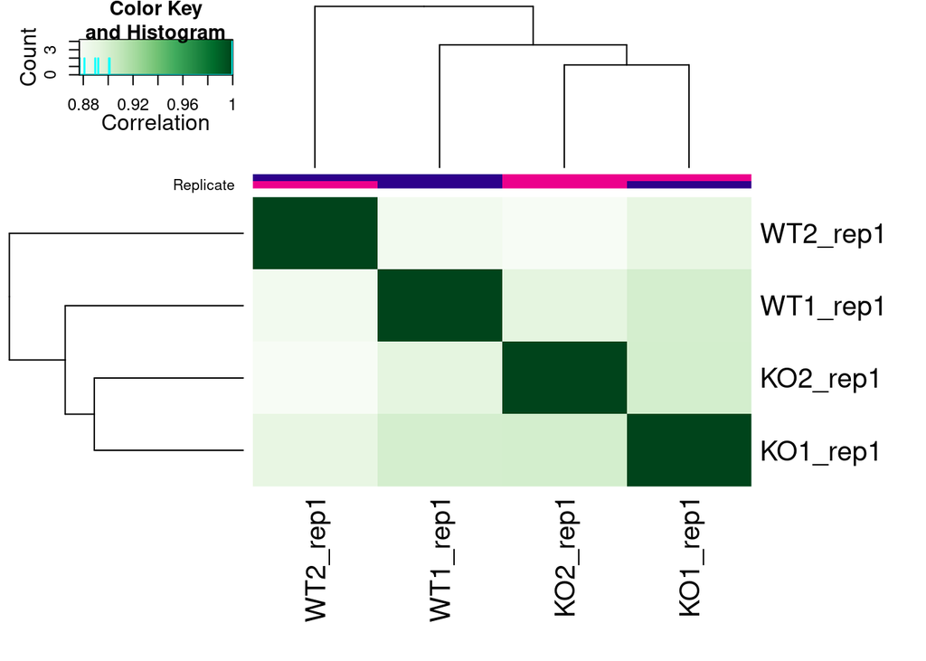

```r
# heatmap
dba.plotHeatmap(dba_cdc1)
```

We will now repeat the same process for analysis of cDC2 cells.

```r
dba_cdc2 <- dba(sampleSheet = samples_cdc2)

dba_cdc2 <- dba.count(dba_cdc2, minOverlap = 2, score = DBA_SCORE_TMM_MINUS_FULL)

dba_cdc2 <- dba.contrast(dba_cdc2, categories = DBA_CONDITION, minMembers = 2)

dba_cdc2 <- dba.analyze(dba_cdc2, method = DBA_DESEQ2, bBlacklist = FALSE, bGreylist = FALSE)

diff_cdc2_df <- as.data.frame(dba.report(dba_cdc2, th = 1, bCounts = FALSE))
diff_cdc2_df$significant <- diff_cdc2_df$p.value < 0.01

write.csv(diff_cdc2_df, "results/diffbind/cdc2_diffbind_results.csv", row.names = FALSE)
write.table(diff_cdc2_df[diff_cdc2_df$p.value < 0.01, c("seqnames", "start", "end")],
            "results/diffbind/cdc2_significant_peaks.bed",
            sep = "\t", quote = FALSE, row.names = FALSE, col.names = FALSE)
```

Then, we will generate the same visualizations for cDC2 cells.

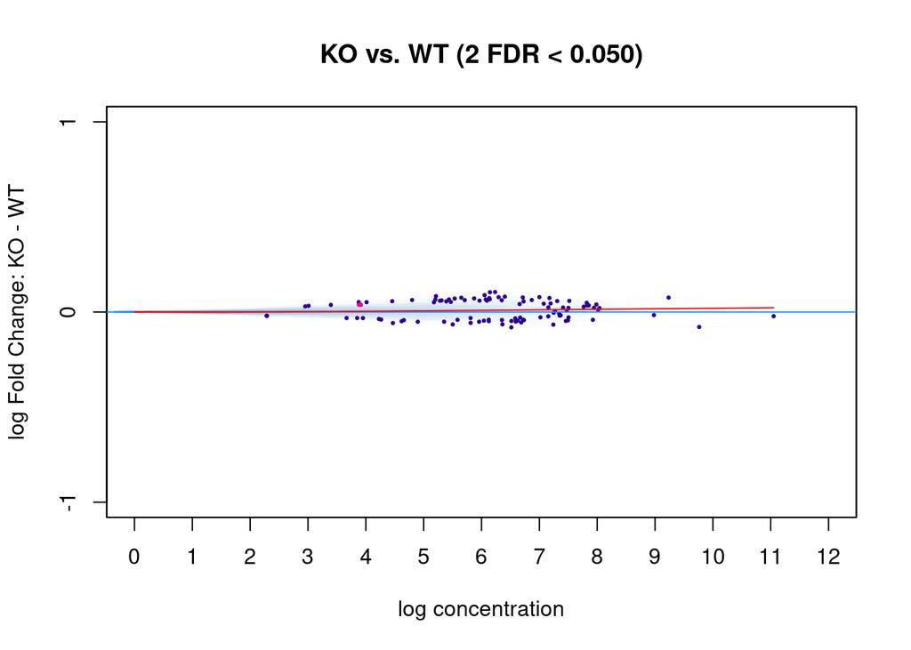

```r
dba.plotMA(dba_cdc2)
```

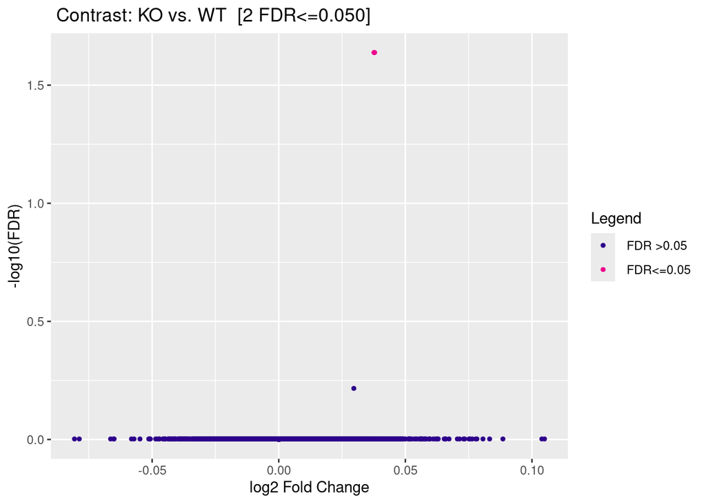

```r
dba.plotVolcano(dba_cdc2)
```

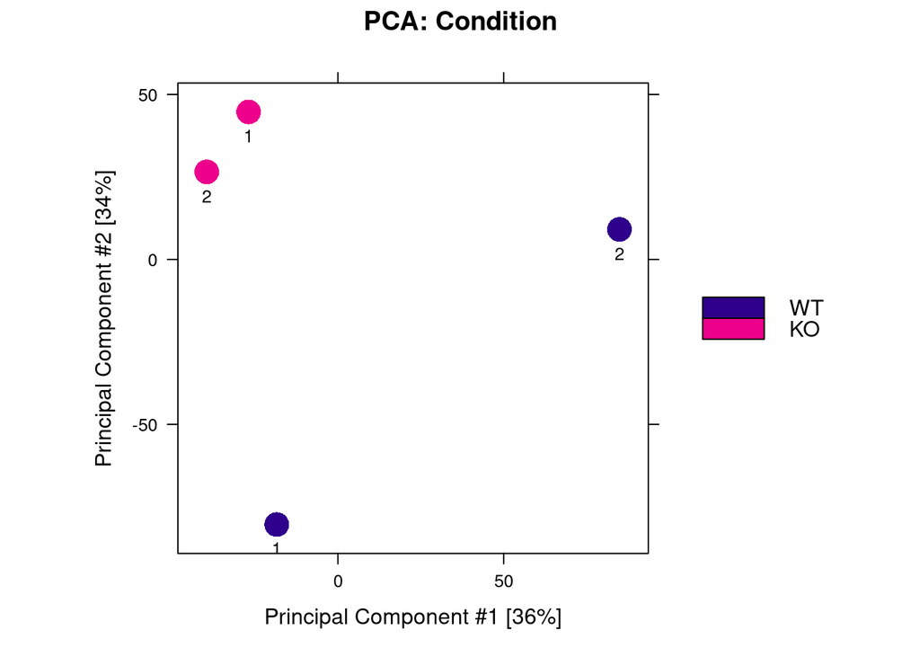

```r
dba.plotPCA(dba_cdc2, attributes = DBA_CONDITION, label = DBA_REPLICATE)
```

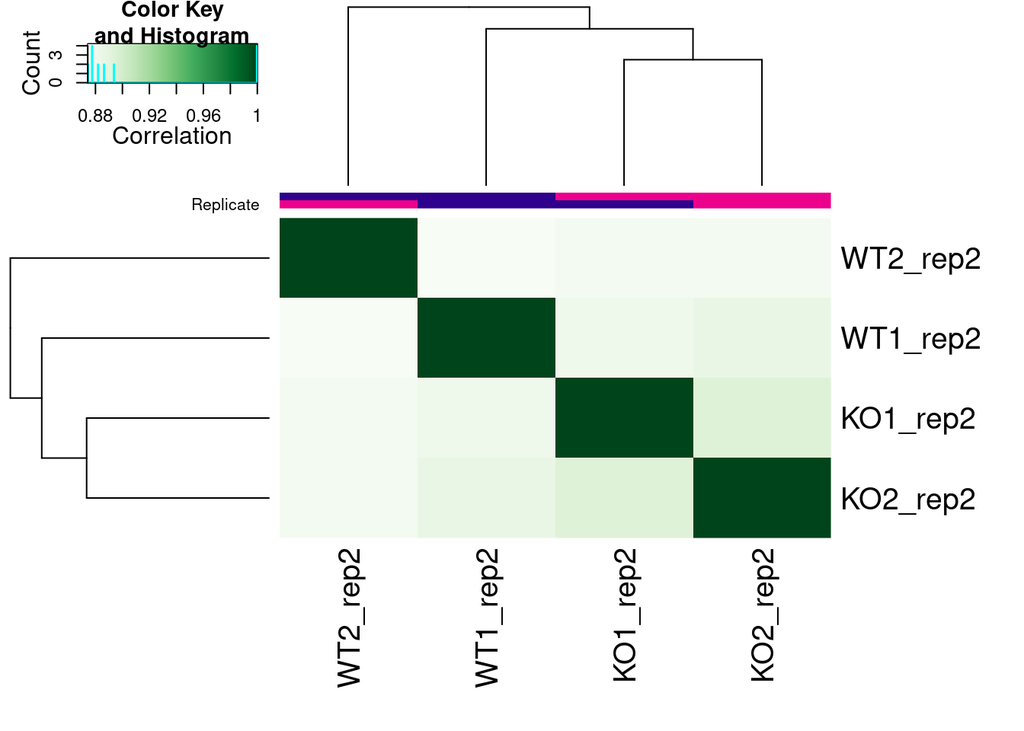

```r
dba.plotHeatmap(dba_cdc2)
```

We will now print summary statistics, which show the total number of peaks analyzed and the total number of significantly different peaks.

```r
cat("cDC1: Total =", nrow(diff_cdc1_df), "| Sig (p<0.01) =", sum(diff_cdc1_df$p.value < 0.01), "\n")
```

```
## cDC1: Total = 15029 | Sig (p<0.01) = 13
```

```r
cat("cDC2: Total =", nrow(diff_cdc2_df), "| Sig (p<0.01) =", sum(diff_cdc2_df$p.value < 0.01), "\n")
```

```
## cDC2: Total = 18690 | Sig (p<0.01) = 13
```